# Spotify Tracks dataset

Sushma akoju

9/15/2021

## Dataset Description

#### Spotify Tracks Dataset is about playlist features and how they compare by genre or album/artist ids w.r.t popularity, acoustic ness, danceability, energy, instrumentals, key (musical chords) etc. Since all of us commonly listen to music, we found it interesting to explore various factors and their influence on playlists that become popular.

## About the features

#### It seems that Spotify has defined features based on various audio acoustic features such as Shimmer, pitch, tone, fundamental frequency, etc as well as musical acoustics. https://developer.spotify.com/documentation/web-api/reference/#endpoint-get-audio-features The audio features seem to be based on pitch ranges, harmonics, overtones of musical instruments along with known vocal quality metrics based on features such as jitter, shimmer, pitch, tone etc. Each musical acoustics, as well as voice acoustics, are analyzed based on defined audio signal processing standards.

## Goal

#### We primarily focus and attempt to understand each of the features, their technical definitions cited here https://developer.spotify.com/documentation/web-api/reference/#endpoint-get-audio-features . we would like to see how existing human notions about music fare against what data actually tells us about. For example, it has been widely popular that the C# chord is most popular in western music. We want to find out how the features contribute to popularity.

```r
#rcurl <- getURL("https://www.kaggle.com/zaheenhamidani/ultimate-spotify-tracks-db/download")
data_url <- "https://raw.githubusercontent.com/sushmaakoju/spotify-tracks-data-analysis/main/SpotifyFeatures.csv"
column_names <- c("genre","artist_name","track_name","track_id","popularity","acousticness","danceability","duration_ms","energy","instrumentalness","key","liveness","loudness","mode","speechiness","tempo","time_signature","valence")
spotifydf <- read_csv(data_url, show_col_types=FALSE)
head(spotifydf)
```

```
## # A tibble: 6 x 18
##   genre artist_name  track_name   track_id  popularity acousticness danceability
##   <chr> <chr>        <chr>        <chr>          <dbl>        <dbl>        <dbl>
## 1 Movie Henri Salva~ C'est beau ~ 0BRjO6ga~          0        0.611        0.389
## 2 Movie Martin & le~ Perdu d'ava~ 0BjC1Nfo~          1        0.246        0.59
## 3 Movie Joseph Will~ Don't Let M~ 0CoSDzoN~          3        0.952        0.663
## 4 Movie Henri Salva~ Dis-moi Mon~ 0Gc6TVm5~          0        0.703        0.24
## 5 Movie Fabien Nataf Ouverture    0IuslXpM~          4        0.95         0.331
## 6 Movie Henri Salva~ Le petit so~ 0Mf1jKa8~          0        0.749        0.578
## # ... with 11 more variables: duration_ms <dbl>, energy <dbl>,
## #   instrumentalness <dbl>, key <chr>, liveness <dbl>, loudness <dbl>,
## #   mode <chr>, speechiness <dbl>, tempo <dbl>, time_signature <chr>,
## #   valence <dbl>
```

```r
colSums(is.na(spotifydf))
```

```
##            genre      artist_name       track_name         track_id
##                0                0                0                0
##       popularity     acousticness     danceability      duration_ms
##                0                0                0                0
##           energy instrumentalness              key         liveness
##                0                0                0                0
##         loudness             mode      speechiness            tempo
##                0                0                0                0
##   time_signature          valence
##                0                0
```

```r
head( spotifydf)
```

```
## # A tibble: 6 x 18
##   genre artist_name  track_name   track_id  popularity acousticness danceability
##   <chr> <chr>        <chr>        <chr>          <dbl>        <dbl>        <dbl>
## 1 Movie Henri Salva~ C'est beau ~ 0BRjO6ga~          0        0.611        0.389
## 2 Movie Martin & le~ Perdu d'ava~ 0BjC1Nfo~          1        0.246        0.59
## 3 Movie Joseph Will~ Don't Let M~ 0CoSDzoN~          3        0.952        0.663
## 4 Movie Henri Salva~ Dis-moi Mon~ 0Gc6TVm5~          0        0.703        0.24
## 5 Movie Fabien Nataf Ouverture    0IuslXpM~          4        0.95         0.331
## 6 Movie Henri Salva~ Le petit so~ 0Mf1jKa8~          0        0.749        0.578
## # ... with 11 more variables: duration_ms <dbl>, energy <dbl>,
## #   instrumentalness <dbl>, key <chr>, liveness <dbl>, loudness <dbl>,
## #   mode <chr>, speechiness <dbl>, tempo <dbl>, time_signature <chr>,
## #   valence <dbl>
```

```r
glimpse(spotifydf)
```

```
## Rows: 232,725
## Columns: 18
## $ genre            <chr> "Movie", "Movie", "Movie", "Movie", "Movie", "Movie",~
## $ artist_name      <chr> "Henri Salvador", "Martin & les fées", "Joseph Willia~
## $ track_name       <chr> "C'est beau de faire un Show", "Perdu d'avance (par G~
## $ track_id         <chr> "0BRjO6ga9RKCKjfDqeFgWV", "0BjC1NfoEOOusryehmNudP", "~
## $ popularity       <dbl> 0, 1, 3, 0, 4, 0, 2, 15, 0, 10, 0, 2, 4, 3, 0, 0, 0, ~
## $ acousticness     <dbl> 0.61100, 0.24600, 0.95200, 0.70300, 0.95000, 0.74900,~
## $ danceability     <dbl> 0.389, 0.590, 0.663, 0.240, 0.331, 0.578, 0.703, 0.41~
## $ duration_ms      <dbl> 99373, 137373, 170267, 152427, 82625, 160627, 212293,~
## $ energy           <dbl> 0.9100, 0.7370, 0.1310, 0.3260, 0.2250, 0.0948, 0.270~
## $ instrumentalness <dbl> 0.00e+00, 0.00e+00, 0.00e+00, 0.00e+00, 1.23e-01, 0.0~
## $ key              <chr> "C#", "F#", "C", "C#", "F", "C#", "C#", "F#", "C", "G~
## $ liveness         <dbl> 0.3460, 0.1510, 0.1030, 0.0985, 0.2020, 0.1070, 0.105~
## $ loudness         <dbl> -1.828, -5.559, -13.879, -12.178, -21.150, -14.970, -~
## $ mode             <chr> "Major", "Minor", "Minor", "Major", "Major", "Major",~
## $ speechiness      <dbl> 0.0525, 0.0868, 0.0362, 0.0395, 0.0456, 0.1430, 0.953~
## $ tempo            <dbl> 166.969, 174.003, 99.488, 171.758, 140.576, 87.479, 8~
## $ time_signature   <chr> "4/4", "4/4", "5/4", "4/4", "4/4", "4/4", "4/4", "4/4~
## $ valence          <dbl> 0.8140, 0.8160, 0.3680, 0.2270, 0.3900, 0.3580, 0.533~
```

```r
na.omit(spotifydf)
```

```
## # A tibble: 232,725 x 18
##    genre artist_name  track_name   track_id popularity acousticness danceability
##    <chr> <chr>        <chr>        <chr>         <dbl>        <dbl>        <dbl>
##  1 Movie Henri Salva~ C'est beau ~ 0BRjO6g~          0      0.611          0.389
##  2 Movie Martin & le~ Perdu d'ava~ 0BjC1Nf~          1      0.246          0.59
##  3 Movie Joseph Will~ Don't Let M~ 0CoSDzo~          3      0.952          0.663
##  4 Movie Henri Salva~ Dis-moi Mon~ 0Gc6TVm~          0      0.703          0.24
##  5 Movie Fabien Nataf Ouverture    0IuslXp~          4      0.95           0.331
##  6 Movie Henri Salva~ Le petit so~ 0Mf1jKa~          0      0.749          0.578
##  7 Movie Martin & le~ Premières r~ 0NUiKYR~          2      0.344          0.703
##  8 Movie Laura Mayne  Let Me Let ~ 0PbIF9Y~         15      0.939          0.416
##  9 Movie Chorus       Helka        0ST6uPf~          0      0.00104        0.734
## 10 Movie Le Club des~ Les bisous ~ 0VSqZ3K~         10      0.319          0.598
## # ... with 232,715 more rows, and 11 more variables: duration_ms <dbl>,
## #   energy <dbl>, instrumentalness <dbl>, key <chr>, liveness <dbl>,
## #   loudness <dbl>, mode <chr>, speechiness <dbl>, tempo <dbl>,
## #   time_signature <chr>, valence <dbl>
```

```r
genres <- distinct(spotifydf, genre)$genre
genres
```

```
##  [1] "Movie"            "R&B"              "A Capella"        "Alternative"
##  [5] "Country"          "Dance"            "Electronic"       "Anime"
##  [9] "Folk"             "Blues"            "Opera"            "Hip-Hop"
## [13] "Children's Music" "Children’s Music" "Rap"              "Indie"
## [17] "Classical"        "Pop"              "Reggae"           "Reggaeton"
## [21] "Jazz"             "Rock"             "Ska"              "Comedy"
## [25] "Soul"             "Soundtrack"       "World"
```

```r
spotifydf$genre[spotifydf$genre=="Children's Music"] <- "Children’s Music"
spotifydf[!duplicated(spotifydf$track_id),]
```

```
## # A tibble: 176,774 x 18
##    genre artist_name  track_name   track_id popularity acousticness danceability
##    <chr> <chr>        <chr>        <chr>         <dbl>        <dbl>        <dbl>
##  1 Movie Henri Salva~ C'est beau ~ 0BRjO6g~          0      0.611          0.389
##  2 Movie Martin & le~ Perdu d'ava~ 0BjC1Nf~          1      0.246          0.59
##  3 Movie Joseph Will~ Don't Let M~ 0CoSDzo~          3      0.952          0.663
##  4 Movie Henri Salva~ Dis-moi Mon~ 0Gc6TVm~          0      0.703          0.24
##  5 Movie Fabien Nataf Ouverture    0IuslXp~          4      0.95           0.331
##  6 Movie Henri Salva~ Le petit so~ 0Mf1jKa~          0      0.749          0.578
##  7 Movie Martin & le~ Premières r~ 0NUiKYR~          2      0.344          0.703
##  8 Movie Laura Mayne  Let Me Let ~ 0PbIF9Y~         15      0.939          0.416
##  9 Movie Chorus       Helka        0ST6uPf~          0      0.00104        0.734
## 10 Movie Le Club des~ Les bisous ~ 0VSqZ3K~         10      0.319          0.598
## # ... with 176,764 more rows, and 11 more variables: duration_ms <dbl>,
## #   energy <dbl>, instrumentalness <dbl>, key <chr>, liveness <dbl>,
## #   loudness <dbl>, mode <chr>, speechiness <dbl>, tempo <dbl>,
## #   time_signature <chr>, valence <dbl>
```

```r
#spotifydf[(spotifydf$genre=="Children's Music"),]
distinct(spotifydf, genre)$genre
```

```
##  [1] "Movie"            "R&B"              "A Capella"        "Alternative"
##  [5] "Country"          "Dance"            "Electronic"       "Anime"
##  [9] "Folk"             "Blues"            "Opera"            "Hip-Hop"
## [13] "Children’s Music" "Rap"              "Indie"            "Classical"
## [17] "Pop"              "Reggae"           "Reggaeton"        "Jazz"
## [21] "Rock"             "Ska"              "Comedy"           "Soul"
## [25] "Soundtrack"       "World"
```

```r
str(spotifydf)
```

```
## spec_tbl_df [232,725 x 18] (S3: spec_tbl_df/tbl_df/tbl/data.frame)
##  $ genre           : chr [1:232725] "Movie" "Movie" "Movie" "Movie" ...
##  $ artist_name     : chr [1:232725] "Henri Salvador" "Martin & les fées" "Joseph Williams" "Henri Salvador" ...
##  $ track_name      : chr [1:232725] "C'est beau de faire un Show" "Perdu d'avance (par Gad Elmaleh)" "Don't Let Me Be Lonely Tonight" "Dis-moi Monsieur Gordon Cooper" ...
##  $ track_id        : chr [1:232725] "0BRjO6ga9RKCKjfDqeFgWV" "0BjC1NfoEOOusryehmNudP" "0CoSDzoNIKCRs124s9uTVy" "0Gc6TVm52BwZD07Ki6tIvf" ...
##  $ popularity      : num [1:232725] 0 1 3 0 4 0 2 15 0 10 ...
##  $ acousticness    : num [1:232725] 0.611 0.246 0.952 0.703 0.95 0.749 0.344 0.939 0.00104 0.319 ...
##  $ danceability    : num [1:232725] 0.389 0.59 0.663 0.24 0.331 0.578 0.703 0.416 0.734 0.598 ...
##  $ duration_ms     : num [1:232725] 99373 137373 170267 152427 82625 ...
##  $ energy          : num [1:232725] 0.91 0.737 0.131 0.326 0.225 0.0948 0.27 0.269 0.481 0.705 ...
##  $ instrumentalness: num [1:232725] 0 0 0 0 0.123 0 0 0 0.00086 0.00125 ...
##  $ key             : chr [1:232725] "C#" "F#" "C" "C#" ...
##  $ liveness        : num [1:232725] 0.346 0.151 0.103 0.0985 0.202 0.107 0.105 0.113 0.0765 0.349 ...
##  $ loudness        : num [1:232725] -1.83 -5.56 -13.88 -12.18 -21.15 ...
##  $ mode            : chr [1:232725] "Major" "Minor" "Minor" "Major" ...
##  $ speechiness     : num [1:232725] 0.0525 0.0868 0.0362 0.0395 0.0456 0.143 0.953 0.0286 0.046 0.0281 ...
##  $ tempo           : num [1:232725] 167 174 99.5 171.8 140.6 ...
##  $ time_signature  : chr [1:232725] "4/4" "4/4" "5/4" "4/4" ...
##  $ valence         : num [1:232725] 0.814 0.816 0.368 0.227 0.39 0.358 0.533 0.274 0.765 0.718 ...
##  - attr(*, "spec")=
##   .. cols(
##   ..   genre = col_character(),
##   ..   artist_name = col_character(),
##   ..   track_name = col_character(),
##   ..   track_id = col_character(),
##   ..   popularity = col_double(),
##   ..   acousticness = col_double(),
##   ..   danceability = col_double(),
##   ..   duration_ms = col_double(),
##   ..   energy = col_double(),
##   ..   instrumentalness = col_double(),
##   ..   key = col_character(),
##   ..   liveness = col_double(),
##   ..   loudness = col_double(),
##   ..   mode = col_character(),
##   ..   speechiness = col_double(),
##   ..   tempo = col_double(),
##   ..   time_signature = col_character(),
##   ..   valence = col_double()
##   .. )
##  - attr(*, "problems")=<externalptr>
```

```r
columns <- colnames(spotifydf)
columns
```

```
##  [1] "genre"            "artist_name"      "track_name"       "track_id"
##  [5] "popularity"       "acousticness"     "danceability"     "duration_ms"
##  [9] "energy"           "instrumentalness" "key"              "liveness"
## [13] "loudness"         "mode"             "speechiness"      "tempo"
## [17] "time_signature"   "valence"
```

```r
numeric_columns <- unlist(lapply(spotifydf, is.numeric))
numeric_columns
```

```
##            genre      artist_name       track_name         track_id
##            FALSE            FALSE            FALSE            FALSE
##       popularity     acousticness     danceability      duration_ms
##             TRUE             TRUE             TRUE             TRUE
##           energy instrumentalness              key         liveness
##             TRUE             TRUE            FALSE             TRUE
##         loudness             mode      speechiness            tempo
##             TRUE            FALSE             TRUE             TRUE
##   time_signature          valence
##            FALSE             TRUE
```

```r
numeric_spotifydf <- spotifydf[,numeric_columns]
colnames(numeric_spotifydf)
```

```
##  [1] "popularity"       "acousticness"     "danceability"     "duration_ms"
##  [5] "energy"           "instrumentalness" "liveness"         "loudness"
##  [9] "speechiness"      "tempo"            "valence"
```

```r
library(purrr)
library(corrr)
corr_df <- correlate(numeric_spotifydf, quiet = TRUE)
corr_df
```

```
## # A tibble: 11 x 12
##    term             popularity acousticness danceability duration_ms  energy
##    <chr>                 <dbl>        <dbl>        <dbl>       <dbl>   <dbl>
##  1 popularity         NA            -0.381        0.257      0.00235  0.249
##  2 acousticness       -0.381        NA           -0.365      0.0112  -0.726
##  3 danceability        0.257        -0.365       NA         -0.126    0.326
##  4 duration_ms         0.00235       0.0112      -0.126     NA       -0.0305
##  5 energy              0.249        -0.726        0.326     -0.0305  NA
##  6 instrumentalness   -0.211         0.316       -0.365      0.0760  -0.379
##  7 liveness           -0.168         0.0690      -0.0417     0.0238   0.193
##  8 loudness            0.363        -0.690        0.439     -0.0476   0.816
##  9 speechiness        -0.151         0.151        0.135     -0.0162   0.145
## 10 tempo               0.0810       -0.238        0.0219    -0.0285   0.229
## 11 valence             0.0601       -0.326        0.547     -0.142    0.437
## # ... with 6 more variables: instrumentalness <dbl>, liveness <dbl>,
## #   loudness <dbl>, speechiness <dbl>, tempo <dbl>, valence <dbl>
```

```r
corr_df %>%
  select(-term) %>%
  map_dbl(~ mean(., na.rm = TRUE))
```

```
##       popularity     acousticness     danceability      duration_ms
##       0.01006108      -0.21783690       0.08277417      -0.02770328
##           energy instrumentalness         liveness         loudness
##       0.12591996      -0.17920267       0.04579923       0.10453055
##      speechiness            tempo          valence
##       0.05363949       0.01912414       0.08392748
```

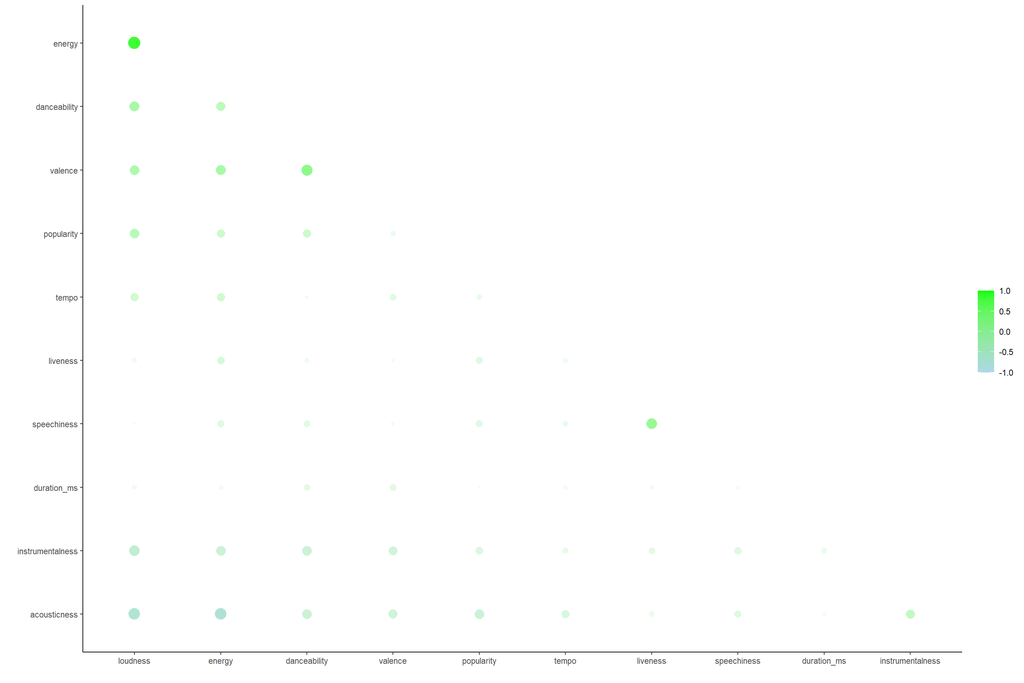

```r
corr_df %>%
  focus(popularity:valence, mirror = TRUE) %>%
  rearrange(absolute = FALSE) %>%
  shave() %>%
  rplot(colors = c("lightblue", "green"), legend = TRUE)
```

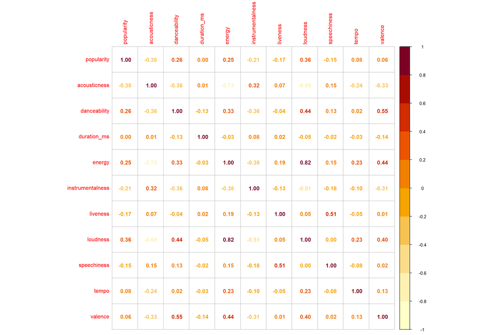

```r
corr_df2 <- cor(numeric_spotifydf)
col3 = hcl.colors(10, "YlOrRd", rev = TRUE)
corrplot(corr_df2, col=col3, method = 'number')
```

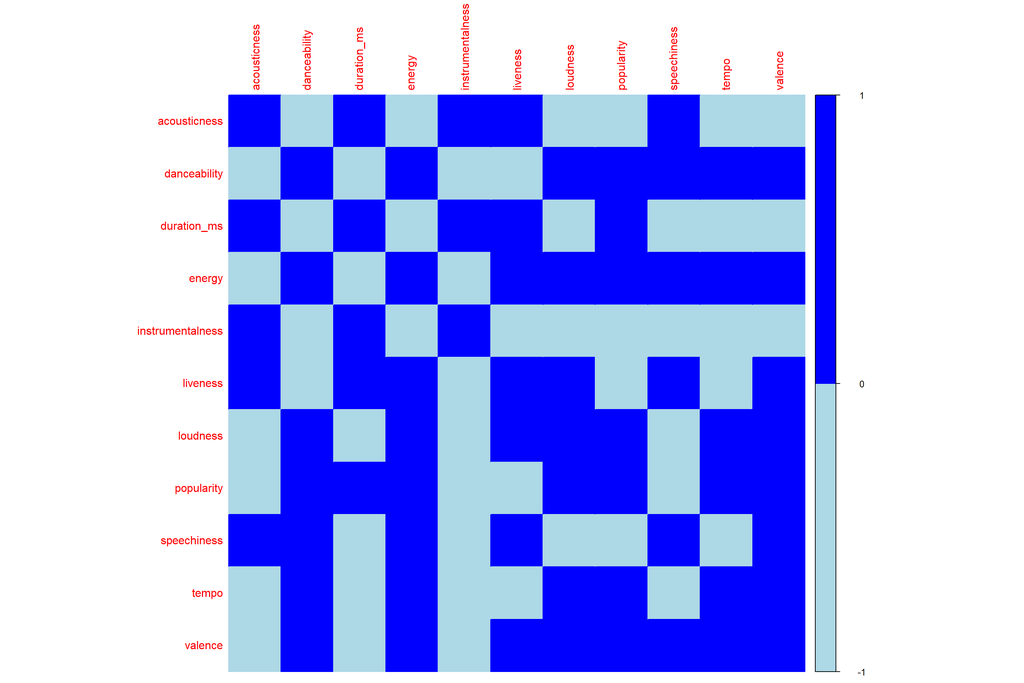

```r
corrplot(corr_df2,  col= c("lightblue", "blue"),method = 'color', order = 'alphabet')
```

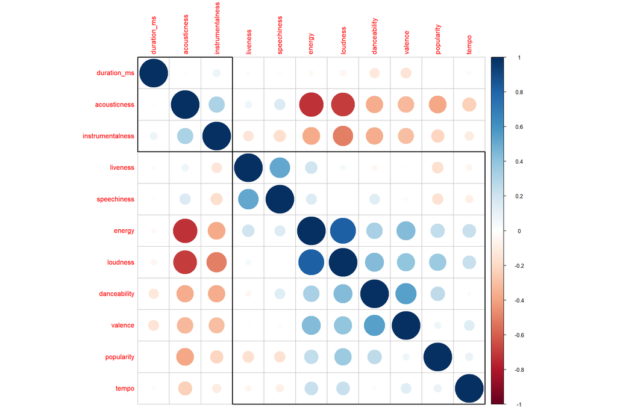

```r
corrplot(corr_df2,  order = 'hclust', addrect = 2)
```

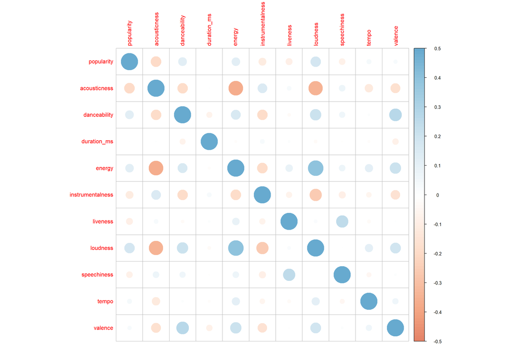

```r
corrplot(corr_df2/2, col.lim=c(-0.5, 0.5))
```

```r
# colorful number
```